# 6 Fine-Tuning Gemma Embedding 300M

- Show All Code
- Hide All Code
- View Source

Domain Adaptation via SimCSE for AI & Technology Media Retrieval

Published

March 21, 2026

# 7 Introduction

Classical embedding models such as Word2Vec and FastText remain strong baselines for many NLP tasks. However, the [MTEB Leaderboard](https://huggingface.co/spaces/mteb/leaderboard) — the standard benchmark for text embeddings — is today dominated entirely by transformer-based architectures.

Among these, **[`google/embeddinggemma-300m`](https://huggingface.co/google/embeddinggemma-300m)** stands out: ranked **14th globally** as of March 13th, 2026, it achieves this with only 300 million parameters, competing with models five or more times its size. This chapter documents an attempt to fine-tune it on our internal AI & technology media corpus to improve downstream RAG retrieval quality.

## 7.1 Model Overview

`gemma-embedding-300m` is a **bi-encoder** distilled from Gemini. Unlike the original causal architecture, it uses bidirectional attention, making it functionally equivalent to an encoder. Its output is a 768-dimensional dense vector optimised for cosine similarity.

| Property | Value |
| --- | --- |
| Parameters | 300M |
| MTEB Rank | #14 (March 2026) |
| Embedding dimension | 768 |
| Max input tokens | 2048 |
| Attention | Bidirectional |

# 8 Approach

## 8.1 Why Fine-Tune?

`gemma-embedding-300m` was pre-trained on a broad web corpus. Its embedding space reflects the general distribution of internet text, not the specific vocabulary and framing of AI & technology journalism. Fine-tuning nudges the geometry of the space so that domain-specific concepts cluster more tightly.

This is **not** task learning. It is domain familiarisation — updating the model’s representations before a later supervised stage trains a specific retrieval skill on top.

## 8.2 The SimCSE Loss

We use **Unsupervised SimCSE** (Gao et al., 2021). The same sentence is passed twice through the model; stochastic dropout produces two slightly different embeddings that form the positive pair. All other sentences in the batch are implicit negatives.

|  | SimCSE — Phase 1 (this chapter) | Supervised pairs — Phase 2 (future) |
| --- | --- | --- |
| Labels required | No | Yes — query/passage pairs |
| Positive pair source | Dropout noise | Annotated or synthetic |
| Negative pair source | In-batch sentences | Hard-mined negatives |
| Goal | Domain knowledge | Retrieval skill |

Since SimCSE requires no labels and only touches internal representations, the full 436,000-chunk corpus remains available for Phase 2 supervised training — the two stages are complementary.

**NoteFluid vs. Crystallised Intelligence**

Phase 1 (SimCSE) expands the model’s domain *knowledge* — its fluid, general representations. Phase 2 (supervised pairs) would then train a specific retrieval *skill* on top of that richer foundation. The same corpus can serve both stages without conflict.

# 9 Evaluation Design

Evaluation follows two tracks:

- **Intrinsic**: cosine similarity on synthetic positive/negative article pairs — tests whether the embedding space geometry is well-ordered.
- **Extrinsic**: macro F1 of a logistic regression probe trained on frozen embeddings, for *sentiment* and *topic* classification.

## 9.1 Intrinsic Evaluation Set

Because `gemma-embedding-300m` uses contextual subword representations, Word2Vec-style analogy tests are not applicable. Instead, we construct synthetic pairs via **back-translation** using [`facebook/nllb-200-distilled-600M`](https://huggingface.co/facebook/nllb-200-distilled-600M):

- **Positive** — `n_pass=3, temp=1.0`: meaning preserved, phrasing varied.
- **Negative** — `n_pass=3, temp=1.1`: semantic drift introduced through noise accumulation.

A well-ordered model should score positive pairs higher than negative ones. The **gap** between the two means is the key metric.

**TipEffect of Temperature and Passes**

At `temp=1.0`, the model consistently picks high-probability tokens and meaning is mostly preserved across passes. At `temp=1.1`, small token-level errors compound geometrically — three passes of slightly noisy translation produce meaningful semantic drift.

```python
tokenizer_nllb = AutoTokenizer.from_pretrained("facebook/nllb-200-distilled-600M")
model_nllb     = AutoModelForSeq2SeqLM.from_pretrained("facebook/nllb-200-distilled-600M")

def translate_text(text, temp, top_p, src_lang, tgt_lang):
    tokenizer_nllb.src_lang = src_lang
    inputs = tokenizer_nllb(text, return_tensors="pt")
    tokens = model_nllb.generate(
        **inputs,
        forced_bos_token_id=tokenizer_nllb.convert_tokens_to_ids(tgt_lang),
        max_new_tokens=200,
        do_sample=True, temperature=temp, top_p=top_p,
    )
    return tokenizer_nllb.batch_decode(tokens, skip_special_tokens=True)[0]

def bi_translation(n_pass, text_to_translate, temp=1.0, top_p=0.95,
                   src_lang="eng_Latn", tgt_lang="fra_Latn"):
    original = deepcopy(text_to_translate)
    for _ in range(n_pass):
        sentences = split_sentences(text_to_translate)
        fwd = [translate_text(s, temp, top_p, src_lang, tgt_lang) for s in sentences]
        bwd = [translate_text(s, temp, top_p, tgt_lang, src_lang) for s in fwd]
        text_to_translate = " ".join(bwd)
    return original, text_to_translate
```

```python
corpus_df     = pd.read_parquet(str(Path(STAGE2_DIR, "corpus_chunks.parquet")))
chunks_sample = corpus_df.chunked_content.sample(n=50, random_state=25)

synth_pair             = chunks_sample.reset_index()
synth_pair["positive"] = synth_pair.chunked_content.apply(
    lambda x: bi_translation(n_pass=3, text_to_translate=x, temp=1.0, top_p=0.99)[1]
)
synth_pair["negative"] = synth_pair.chunked_content.apply(
    lambda x: bi_translation(n_pass=3, text_to_translate=x, temp=1.1, top_p=0.99)[1]
)
synth_pair.to_parquet(str(Path(REPO_ROOT, "notebook/stage2/results", "synth_chunks.parquet")))
```

A few examples from the constructed set:

```python
synth_pair = pd.read_parquet(str(Path(REPO_ROOT, "notebook/stage2/results","synth_chunks.parquet")))

for i, row in synth_pair.iterrows():
    if i == 2:
        break
    print(f"ORIGINAL:\n{row['chunked_content']}\n")
    print(f"POSITIVE (low-noise):\n{row['positive']}\n")
    print(f"NEGATIVE (high-noise):\n{row['negative']}\n")
    print("─" * 60)
```

```
ORIGINAL:
So, the answer: Thursday mornings are the best day and time to send an email, followed closely by Tuesday and Wednesday. That said, perform your own A/B tests to determine the right time and day for your brand.

POSITIVE (low-noise):
We replied that Friday morning was the best time to email, followed closely by Tuesday and Wednesday. But you can use your own A/B testing to determine the time and date for your brand.

NEGATIVE (high-noise):
So you could answer this question on Thursday morning, which is better for journalism and journalism alike. A large number of initiatives to address regional poverty are needed.

────────────────────────────────────────────────────────────
ORIGINAL:
Over the last year, I began to integrate some GenAI tools more and more into my daily work. I tried different GenAI tools and different use cases.

POSITIVE (low-noise):
Last year, I began to incorporate more of the GenAI tools into my everyday assignments. I've tried other tools myself before.

NEGATIVE (high-noise):
During this year, I joined the different 'electric data defense agencies'. With the tools of my daily work, I used some tools and some bright books.

────────────────────────────────────────────────────────────
```

# 10 Training

## 10.1 Dataset

```python
corpus_df = pd.read_parquet(str(Path(STAGE2_DIR, "corpus_chunks.parquet")))
corpus_ds = Dataset.from_pandas(corpus_df)
print(corpus_ds.features)
print(f"\nTotal chunks: {len(corpus_ds):,}")
```

```
{'media_id': Value('int64'), 'chunked_content': Value('large_string'), 'tokens': Value('large_string'), 'sentiment': Value('large_string')}

Total chunks: 436,038
```

The SimCSE format is minimal — anchor and positive are identical; dropout handles the rest:

```python
training_dataset = Dataset.from_dict({
    "anchor":   corpus_ds["chunked_content"],
    "positive": corpus_ds["chunked_content"],
})
```

## 10.2 Model & Hardware

**WarningGated Model**

`google/embeddinggemma-300m` requires accepting Google’s licence on Hugging Face, and a preview branch of `transformers`:

```bash
pip install git+https://github.com/huggingface/transformers@v4.56.0-Embedding-Gemma-preview
```

```python
from huggingface_hub import login
login()
```

```python
device = (
    "mps"  if torch.backends.mps.is_available() else
    "cuda" if torch.cuda.is_available()          else
    "cpu"
)
print(f"Training device: {device}")
```

```python
model = SentenceTransformer(
    "google/embeddinggemma-300m",
    model_card_data=SentenceTransformerModelCardData(
        language="en",
        license="apache-2.0",
        model_name="EmbeddingGemma-300m — Anacode AI Trend Media (SimCSE)",
    ),
)
```

## 10.3 Training Configuration

```python
logging.basicConfig(
    format="%(asctime)s - %(message)s",
    datefmt="%Y-%m-%d %H:%M:%S",
    level=logging.INFO,
)

loss     = MultipleNegativesRankingLoss(model)  # SimCSE by default
run_name = "gemma-embedding-300m-simcse-ai-trend"

args = SentenceTransformerTrainingArguments(
    output_dir=f"notebook/stage2/models/{run_name}",
    num_train_epochs=1,              # single pass — gentle domain nudge
    per_device_train_batch_size=64,  # larger batch → more negatives → stronger signal
    learning_rate=1e-5,
    warmup_ratio=0.1,
    max_grad_norm=1.0,               # gradient clipping
    fp16=False,
    bf16=False,
    save_strategy="epoch",
    save_total_limit=2,
    logging_steps=50,
    run_name=run_name,
    report_to="codecarbon",          # CO₂ emission tracking
)

class NaNDetectorCallback(TrainerCallback):
    """Halts training immediately if a NaN gradient is detected."""
    def on_step_end(self, args, state, control, model=None, **kwargs):
        for name, param in model.named_parameters():
            if param.grad is not None and torch.isnan(param.grad).any():
                print(f"NaN gradient at step {state.global_step} in {name}")
                control.should_training_stop = True

trainer = SentenceTransformerTrainer(
    model=model,
    args=args,
    train_dataset=training_dataset,
    loss=loss,
    callbacks=[NaNDetectorCallback()],
)
trainer.train()
model.save_pretrained(f"{str(REPO_ROOT)}/notebook/stage2/models/gemma-embedding-300-domain-adaptation")
```

## 10.4 Training Curves

**Run summary:** 6,814 steps · initial loss 0.002 · final loss 0.001 · improvement 25.1%.

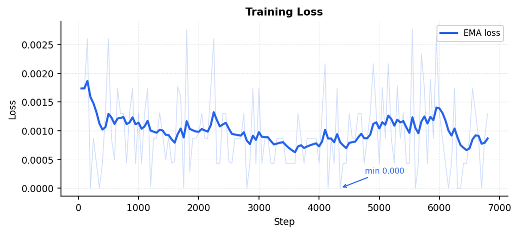

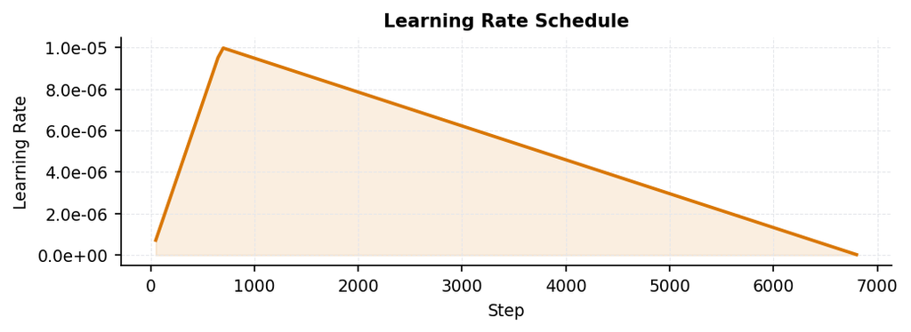

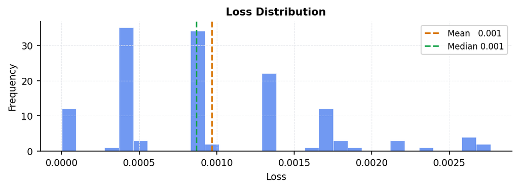

Figure 10.3: Distribution of logged loss values over the full run.

# 11 Evaluation

## 11.1 Intrinsic Performance

```python
synth_chunks = pd.read_parquet(str(Path(REPO_ROOT, "notebook", "stage2", "results", "synth_chunks.parquet")))
intra_result = defaultdict(list)

for i, row in synth_chunks.iterrows():
    intra_result["origin_id"].append(i)
    intra_result["origin"].append(row["chunked_content"])
    for name, mdl in [("pretrained", pretrained_gemma), ("finetuned", finetuned_gemma)]:
        origin = mdl.encode(row["chunked_content"])
        pos    = mdl.encode(row["positive"])
        neg    = mdl.encode(row["negative"])
        intra_result[f"{name}_positive"].append(cosine_similarity(origin, pos))
        intra_result[f"{name}_negative"].append(cosine_similarity(origin, neg))

pd.DataFrame(intra_result).to_parquet(str(Path(REPO_ROOT, "notebook", "stage2", "results", "intrinsic_eval_result.parquet")))
```

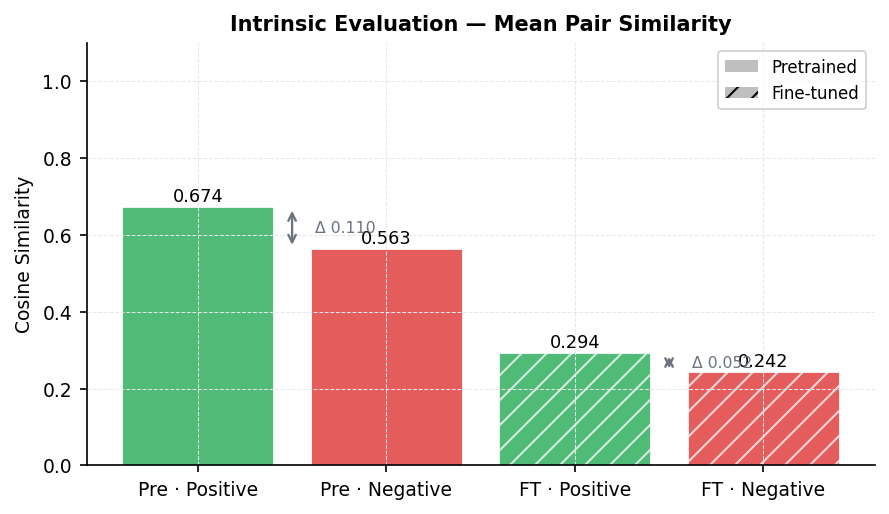

Figure 11.1: Mean cosine similarity for positive and negative synthetic pairs. The gap (Δ) between the two bars is the key metric — a larger gap means the model better separates similar from dissimilar articles.

The overall similarity score of between original-positive pairs for the fine-tuned model is low. Moreover, it model achieves a positive-negative gap of 0.052 compared to 0.110 for the pretrained baseline — a clear regression in embedding space quality.

**ImportantRepresentation Regression**

The training disrupted the model’s existing representations. The most likely causes are:

1. **Learning rate too high.** `1e-5` over 436k chunks is a large cumulative parameter displacement for a model that is already well-trained contrastively.
2. **Catastrophic forgetting.** General representations are overwritten by the narrow domain signal.
3. **Weak contrastive signal.** AI/tech news is stylistically homogeneous, making in-batch SimCSE negatives trivially easy and producing shallow gradients.

See Chapter 12 for a corrected recipe.

## 11.2 Extrinsic Performance

Downstream evaluation uses a logistic regression classifier trained on frozen embeddings. Performance here directly reflects embedding quality, not classifier capacity.

```python
train = pd.read_parquet(str(Path(STAGE2_DIR, "train.parquet")))
test  = pd.read_parquet(str(Path(STAGE2_DIR, "test.parquet")))

X_train_pre = np.array([embed(pretrained_gemma, x) for x in train.full_content.values])
X_test_pre  = np.array([embed(pretrained_gemma, x) for x in test.full_content.values])
X_train_ft  = np.array([embed(finetuned_gemma,  x) for x in train.full_content.values])
X_test_ft   = np.array([embed(finetuned_gemma,  x) for x in test.full_content.values])

with open(str(Path(STAGE2_DIR, "gemmaembedding_eval_datasets.pkl")), "wb") as f:
    pickle.dump({
        "X_train_pre": X_train_pre, "X_test_pre": X_test_pre,
        "X_train_ft":  X_train_ft,  "X_test_ft":  X_test_ft,
    }, f)
```

### 11.2.1 Sentiment Analysis

```python
y_train_sent = train.sentiment_label.values
y_test_sent  = test.sentiment_label.values

for name, X_tr, X_te in [
    ("pretrained", X_train_pre, X_test_pre),
    ("finetuned",  X_train_ft,  X_test_ft),
]:
    clf = LogisticRegression(max_iter=1000, random_state=SEED)
    clf.fit(X_tr, y_train_sent)
    y_pred = clf.predict(X_te)
    results[f"{name}-sentiment"] = {
        "macro_f1": f1_score(y_test_sent, y_pred, average="macro"),
        "y_pred":   y_pred,
    }
    print(f"── {name} ──")
    print(classification_report(y_test_sent, y_pred))
```

```
── pretrained ──
                   precision    recall  f1-score   support

(partly) negative       0.82      0.64      0.72       487
          neutral       0.82      0.91      0.86      1995
         positive       0.84      0.70      0.77       782

         accuracy                           0.82      3264
        macro avg       0.83      0.75      0.78      3264
     weighted avg       0.82      0.82      0.82      3264

── finetuned ──
                   precision    recall  f1-score   support

(partly) negative       0.88      0.31      0.46       487
          neutral       0.72      0.95      0.82      1995
         positive       0.83      0.48      0.61       782

         accuracy                           0.74      3264
        macro avg       0.81      0.58      0.63      3264
     weighted avg       0.77      0.74      0.71      3264
```